# Airway data practice

MYu

1/7/2021

This is a practice for RNAseq data analysis.

load this dataset by using data() function

```r
data("airway")
```

check the data by looking head of the data and summary

```r
summary(airway)
```

```
## [1] "RangedSummarizedExperiment object of length 64102 with 0 metadata columns"
```

```r
head(airway)
```

```
## class: RangedSummarizedExperiment
## dim: 6 8
## metadata(1): ''
## assays(1): counts
## rownames(6): ENSG00000000003 ENSG00000000005 ... ENSG00000000460
##   ENSG00000000938
## rowData names(0):
## colnames(8): SRR1039508 SRR1039509 ... SRR1039520 SRR1039521
## colData names(9): SampleName cell ... Sample BioSample
```

airway is a so-called RangedSummarizedExperiment class object. to make it simple, we need to convert it to matrix.

```r
count_data = assay(airway)
head(count_data)
```

```
##                 SRR1039508 SRR1039509 SRR1039512 SRR1039513 SRR1039516
## ENSG00000000003        679        448        873        408       1138
## ENSG00000000005          0          0          0          0          0
## ENSG00000000419        467        515        621        365        587
## ENSG00000000457        260        211        263        164        245
## ENSG00000000460         60         55         40         35         78
## ENSG00000000938          0          0          2          0          1
##                 SRR1039517 SRR1039520 SRR1039521
## ENSG00000000003       1047        770        572
## ENSG00000000005          0          0          0
## ENSG00000000419        799        417        508
## ENSG00000000457        331        233        229
## ENSG00000000460         63         76         60
## ENSG00000000938          0          0          0
```

convert data to dataframe, since dataframe is more familiar to us and easy to use, also add annotation information

```r
anno = as.data.frame(colData(airway))
anno = anno[, c("cell", "dex")]
anno
```

|  | cell | dex |
| --- | --- | --- |
| SRR1039508 | N61311 | untrt |
| SRR1039509 | N61311 | trt |
| SRR1039512 | N052611 | untrt |
| SRR1039513 | N052611 | trt |
| SRR1039516 | N080611 | untrt |
| SRR1039517 | N080611 | trt |
| SRR1039520 | N061011 | untrt |
| SRR1039521 | N061011 | trt |

```r
class(anno)
```

```
## [1] "data.frame"
```

count_data and anno data set will be used for following analysis. count_data should have the colnames the same as rownames of anno

```r
colnames(count_data) == rownames(anno)
```

```
## [1] TRUE TRUE TRUE TRUE TRUE TRUE TRUE TRUE
```

All TRUE mean the colnames of count_data is the same as rownames of anno

Then let’s check how many genes and how many samples in count_data, we need the total number of counts as library size to do gene normalization to remove systematic bias.

```r
dim(count_data)
```

```
## [1] 64102     8
```

```r
nrow(count_data)
```

```
## [1] 64102
```

```r
library_size = colSums(count_data)
library_size
```

```
## SRR1039508 SRR1039509 SRR1039512 SRR1039513 SRR1039516 SRR1039517 SRR1039520
##   20637971   18809481   25348649   15163415   24448408   30818215   19126151
## SRR1039521
##   21164133
```

Use DESeq2 to do the normalization. DESeq2 normalization is a more advanced method. To show the problem when comparing counts for two samples:

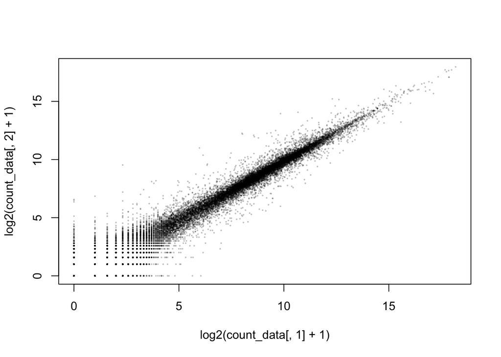

```r
plot(log2(count_data[,1]+1), log2(count_data[,2]+1), pch=16, cex= 0.3, col="#00000040")
```

Just compare the first two column of samples, we can see for the lowly expressed genes, the cross-sample variance gets higher. We can also observe if we directly plot the cross-sample mean verse cross-sample standard deviation:

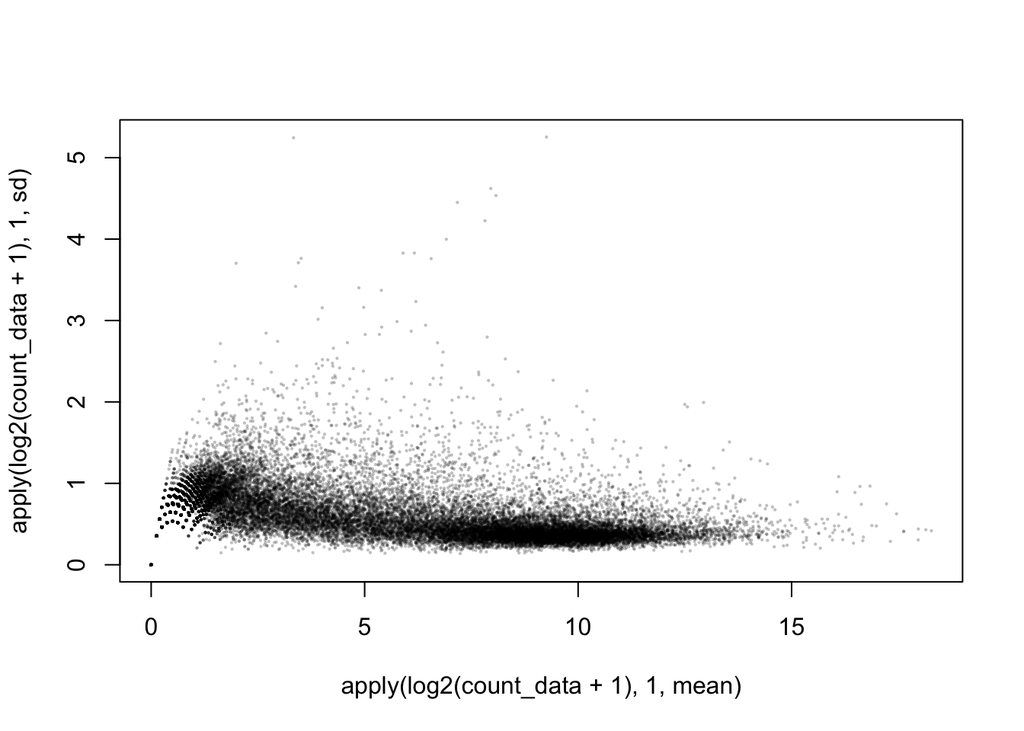

```r
plot(apply(log2(count_data +1), 1, mean), apply(log2(count_data+1),1,sd), pch=16, cex= 0.3, col="#00000040")
```

It shows clearly the standard deviation increase for the lowly expressed genes, which means the variance is bigger in lowly expressed genes.

DESeq2 package provides a function vst() which applies an algorithm called “variance Stabilization” and can reduce the noise from lowly expressed genes.

Applying DESeq2 normalization is simple, just call vst() function:

```r
library(DESeq2)
d_count = vst(count_data)
```

Now we make the scatterplot for the first and the second samples with the DESeq2 normalized values.

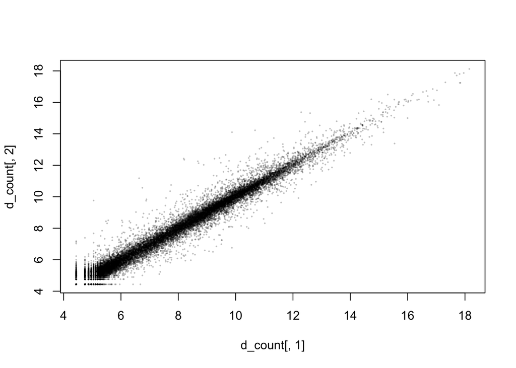

```r
plot(d_count[,1], d_count[,2],pch=16, cex= 0.3, col="#00000040")
```

After apply vst function, the variance is more stable now

In following sections, we use the normalized matrix deseq2 for analysis. First we look at the qunatiles of each column:

```r
apply(d_count, 2, quantile)
```

```
##      SRR1039508 SRR1039509 SRR1039512 SRR1039513 SRR1039516 SRR1039517
## 0%     4.436956   4.436956   4.436956   4.436956   4.436956   4.436956
## 25%    4.436956   4.436956   4.436956   4.436956   4.436956   4.436956
## 50%    4.436956   4.436956   4.436956   4.436956   4.436956   4.436956
## 75%    5.388497   5.347929   5.407320   5.349291   5.368103   5.330474
## 100%  18.150993  18.122258  18.732737  18.640978  18.365899  18.130965
##      SRR1039520 SRR1039521
## 0%     4.436956   4.436956
## 25%    4.436956   4.436956
## 50%    4.436956   4.436956
## 75%    5.388748   5.325035
## 100%  18.650432  18.589353
```

When you have a lot of samples (let’s say more than 20), it is not possible to plot density distributions for all samples. Instead we can use heatmap to show density distributions:

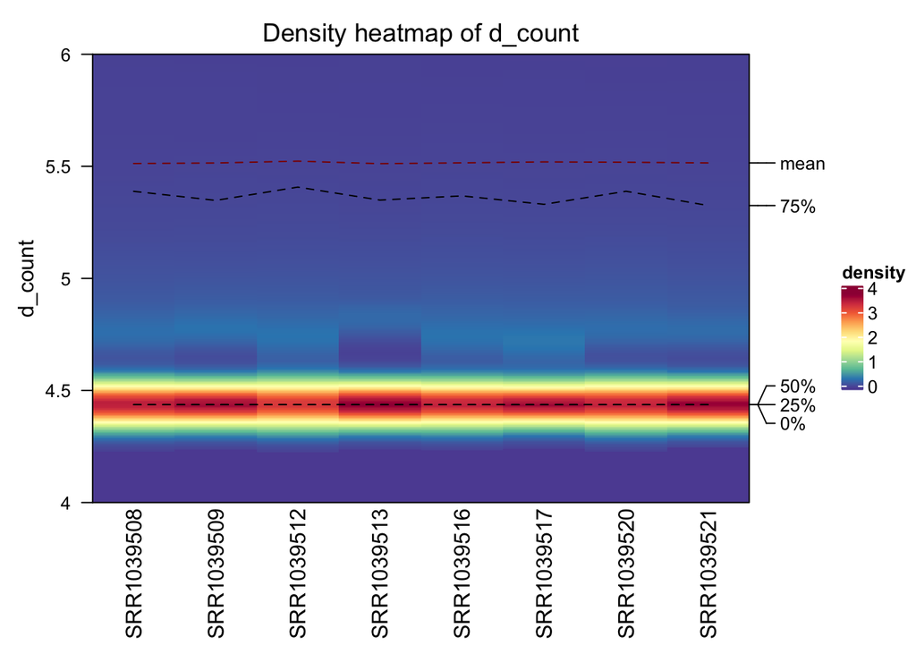

```r
library(ComplexHeatmap)
densityHeatmap(d_count, range = c(4, 6))
```

In the density heatmap, each column corresponds to one sample and colors are used to represent density values in the distribution.

All these statistics and plots (quantiles, density distribution) show the global distribution or pattern are very similar between samples, in other words, there is no “bad samples” and all samples are comparible, and can be taken into downstream analysis.

To make the heatmap and clustering, normally we only extract top n most variable genes.

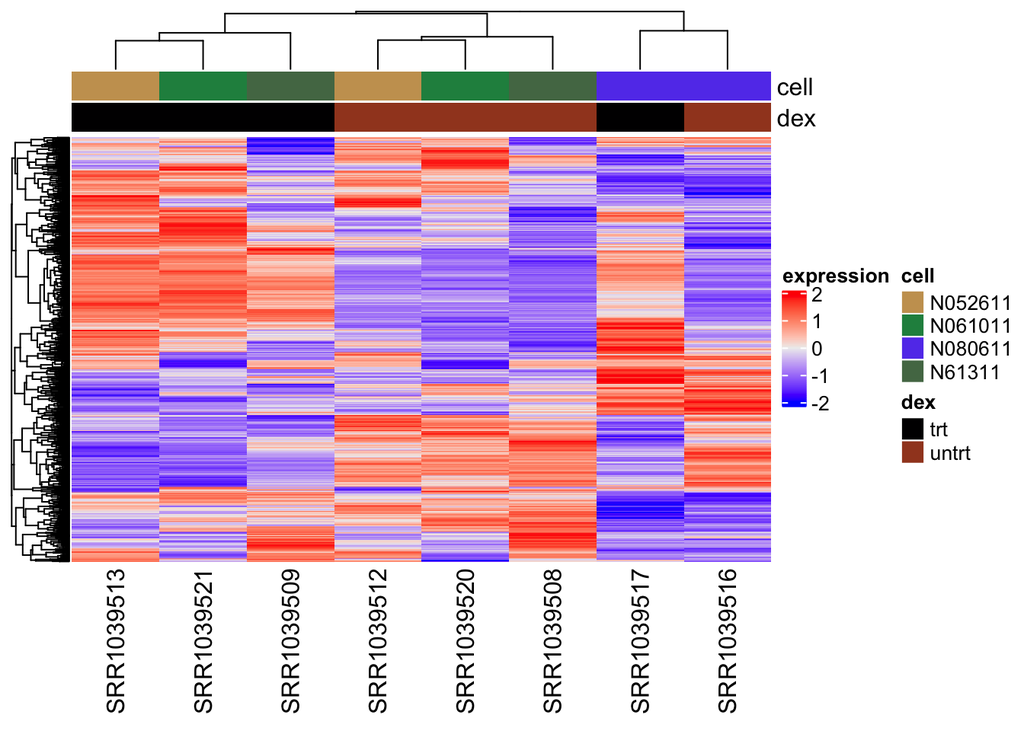

```r
data_sds= apply(d_count, 1, sd)
top_1k_gene= order(data_sds, decreasing = TRUE)[1:1000]
data_h = d_count[top_1k_gene,]
data_h_scale = t(scale(t(data_h)))
Heatmap(data_h_scale, name = "expression", show_row_names = FALSE,
    top_annotation = HeatmapAnnotation(df = anno, show_annotation_name = TRUE)
)
```

The heatmap shows the two “N080611” cell types are more distinct from others while for the remaining samples, the main difference is due to “trt/untrt”.

When cluster columns, hierarchical clustering is not always a good option. Since here we know there are two major groups in columns, we can apply k-means clustering for classification.

```r
km = kmeans(t(data_h_scale), centers = 2)
km = km$cluster
km
```

```
## SRR1039508 SRR1039509 SRR1039512 SRR1039513 SRR1039516 SRR1039517 SRR1039520
##          1          2          1          2          1          2          1
## SRR1039521
##          2
```

Now you can see each samples has a class label (either 1 or 2).

We add the class label from k-means clustering to the heatmap. Note we do not apply hierarchical clustering on columns any more by setting cluster_columns = FALSE.

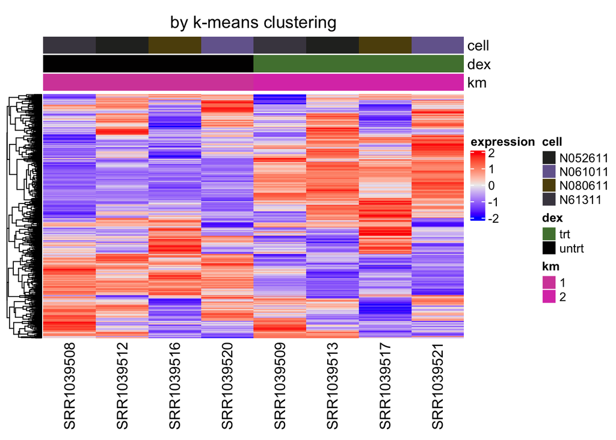

```r
Heatmap(data_h_scale, name = "expression", show_row_names = FALSE,
    top_annotation = HeatmapAnnotation(df = anno, km = as.character(km), show_annotation_name = TRUE),
    cluster_columns = FALSE, column_order = order(km), column_title = "by k-means clustering"
)
```

To make the heatmap and clustering, normally we only extract top 50 most variable genes.

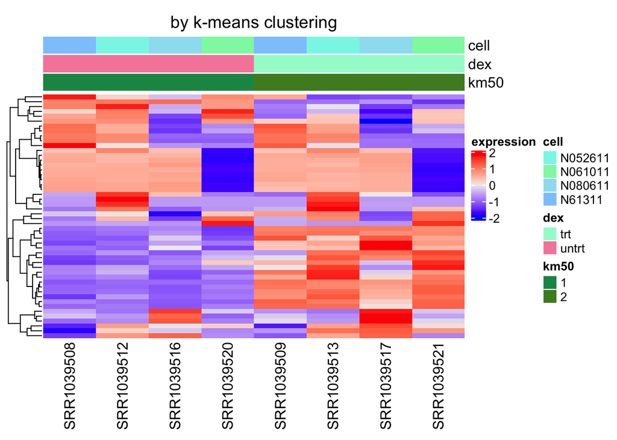

```r
top_50_gene= order(data_sds, decreasing = TRUE)[1:50]
data_h50 = d_count[top_50_gene,]
data_h50_scale = t(scale(t(data_h50)))
km50 = kmeans(t(data_h50_scale), centers = 2)
km50 = km50$cluster
Heatmap(data_h50_scale, name = "expression", show_row_names = FALSE,
    top_annotation = HeatmapAnnotation(df = anno, km50 = as.character(km50), show_annotation_name = TRUE),
    cluster_columns = FALSE, column_order = order(km50), column_title = "by k-means clustering")
```